# Midterm Report

I am starting with cleaning the data and then separating it into 4 data sets: California census, California survey, Florida census, and Florida survey.

# California

All the data cleaning for California is done in this section.

## Census Data

In this section, I’m cleaning the census data for California. This is where I am getting the information for the operations vs producers section.

## Survey Data

I am cleaning the survey data for California in this section. Here is where I am discovering the information I use for California’s chemical analysis.

# Florida

All the data cleaning for Florida is done in this section.

## Census Data

In this section, I’m cleaning the census data for Florida. Similarly to California, this is where I am getting the information for the operations vs producers section.

## Survey Data

I am cleaning the survey data for Florida in this section. Like with California, here is where I am discovering the information I use for Florida chemical analysis.

# Chemical Analysis

First, I’m comparing the top 5 chemicals used in each state.

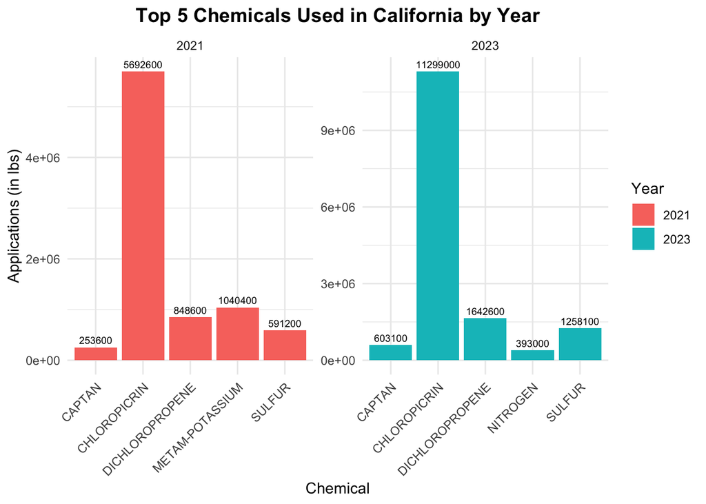

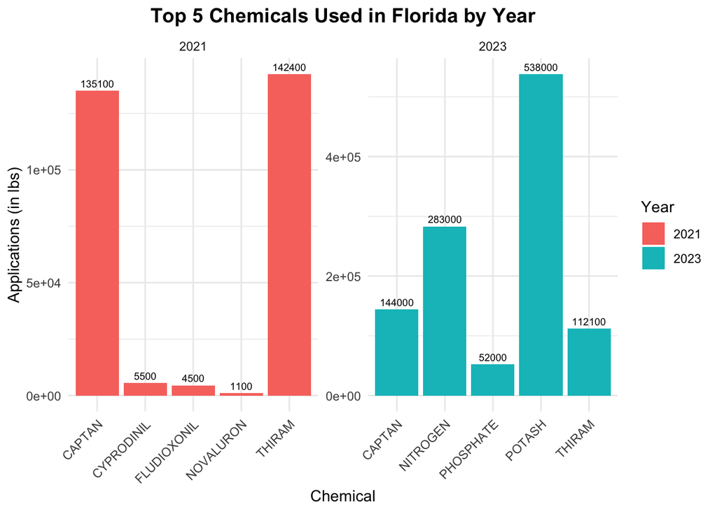

Now I’m comparing the the bottom 5 chemicals used in each state.

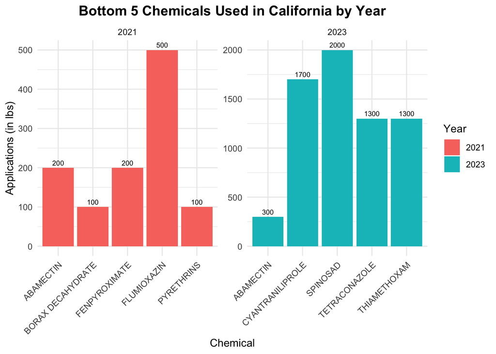

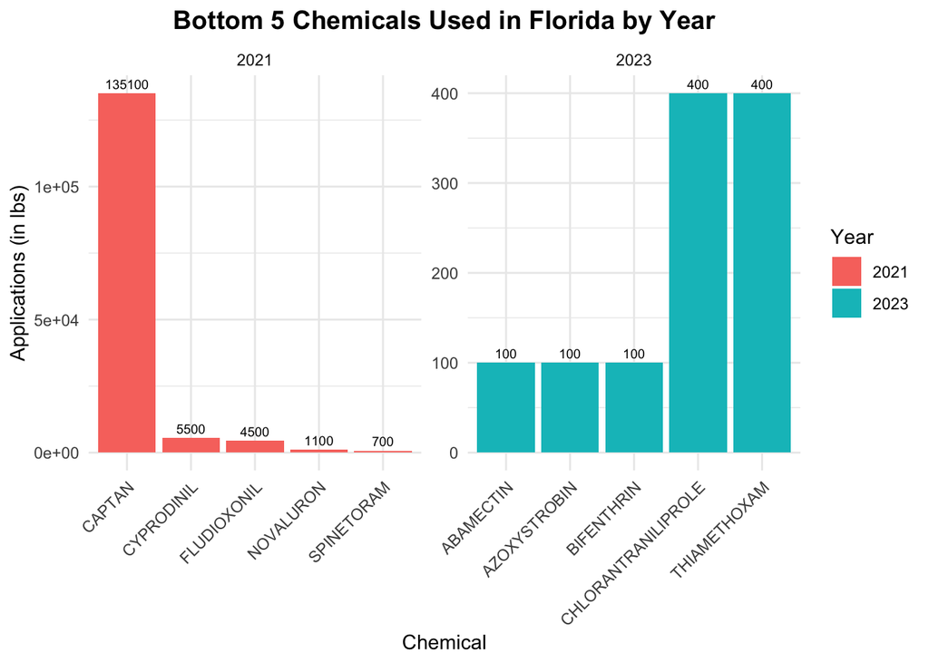

Based on the above graphs, shared chemicals between the top 5 chemicals in each state include captan and nitrogen, and the bottom 5 chemicals in each state include abamectin and thiamethoxam. Using this information, I will compare the usage of captan, nitrogen, and abamectin between California and Florida.

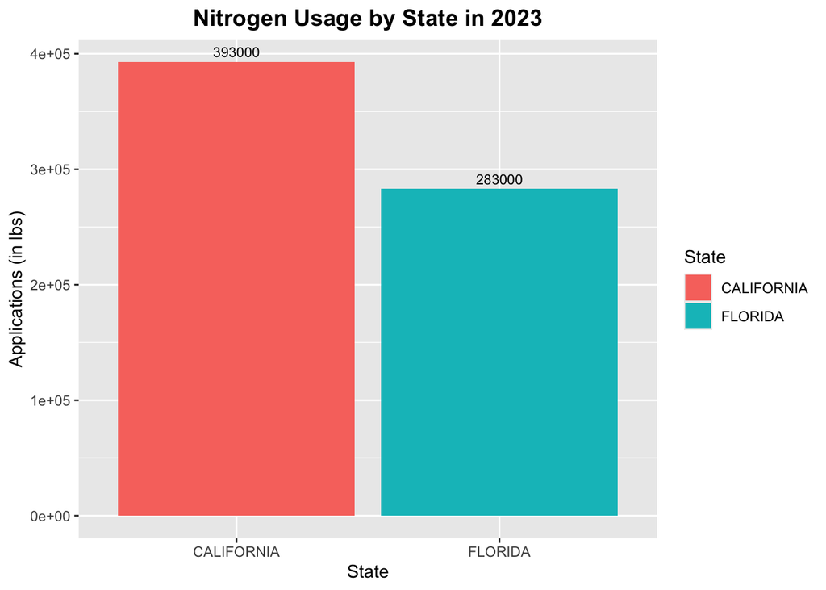

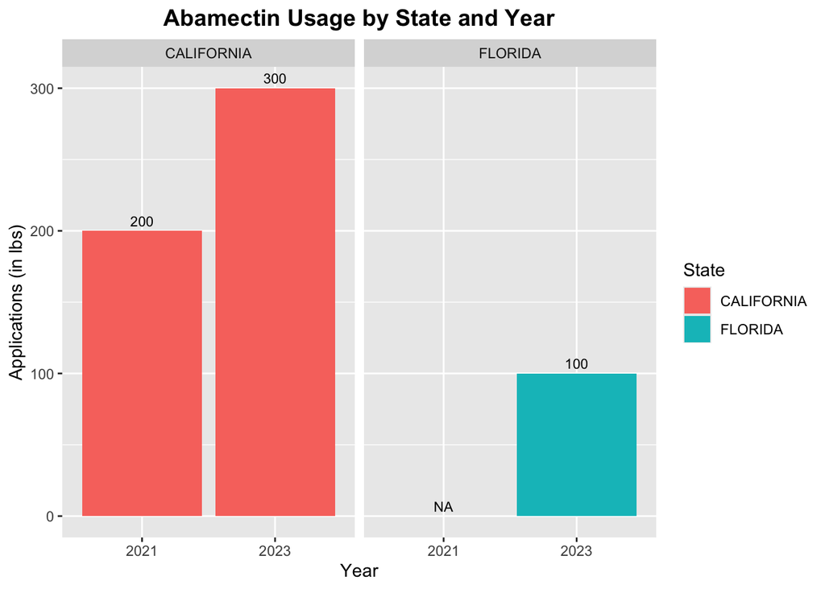

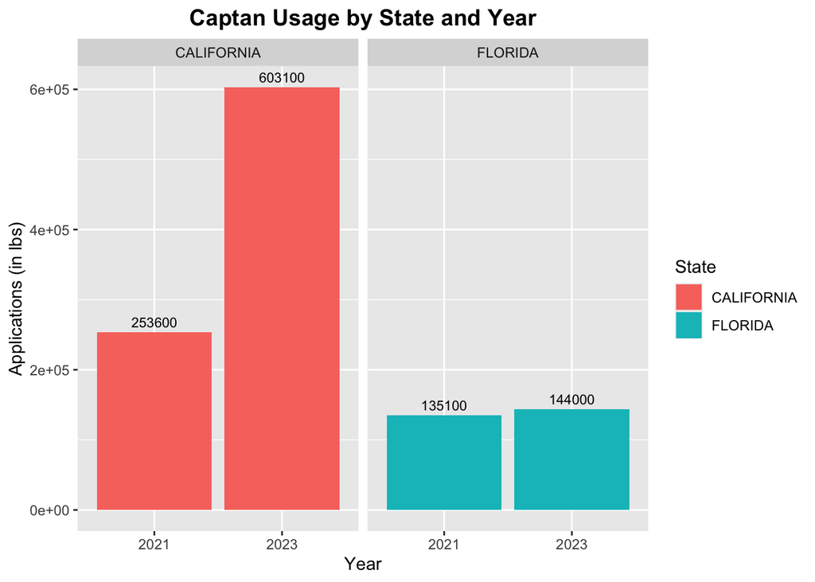

Nitrogen was only used in 2023 in both California and Florida. There is a 110,000 lb difference in application between states. I wonder if this is due to California producing more strawberries than Florida. Also, why is there no nitrogen usage in 2021 for both states?

In regard to abamectin, both California and Florida used more in 2023 than 2021. Although Florida in 2021 doesn’t have any data, I will assume that there was little to no usage. If I assume there is no usage, then both California and Florida use 100 lbs more in 2023 than in 2021.

However, the difference in captan usage between states is drastic. There is a 349,500 lb difference between 2021 and 2023 in California and a 8,900 lb difference between 2021 and 2023 in Florida. What happened between 2021 and 2023 in California for the dramatic increase in captan usage? And why is there such a small difference in captan usage from 2021 to 2023 in Florida while there’s a huge difference in California?

# Operations vs Producers

Comparison of California's Producers and Operations Net Income in 2022 by Area Operated

| Area Range (acres) Low | Area Range (acres) High | Producers Value ($).x | Operations Value ($).y | Difference Difference in y-x ($) |
| --- | --- | --- | --- | --- |
| 1 | 9.9 | -46056000 | -33586000 | 12470000 |
| 10 | 49.9 | 357332000 | 376405000 | 19073000 |
| 50 | 69.9 | 134158000 | 150061000 | 15903000 |
| 70 | 99.9 | 236584000 | 253660000 | 17076000 |
| 100 | 139.0 | 191307000 | 223317000 | 32010000 |
| 140 | 179.0 | 253627000 | 285520000 | 31893000 |
| 180 | 219.0 | 282964000 | 282080000 | -884000 |
| 220 | 259.0 | 126638000 | 129012000 | 2374000 |
| 260 | 499.0 | 1321748000 | 1355260000 | 33512000 |
| 500 | 999.0 | 1847524000 | 2007260000 | 159736000 |
| 1000 | 1999.0 | 1892878000 | 1927889000 | 35011000 |
| 2000 | NA | 5075486000 | 5147340000 | 71854000 |

Comparison of Florida's Producers and Operations Net Income in 2022 by Area Operated

| Area Range (acres) Low | Area Range (acres) High | Producers Value ($).x | Operations Value ($).y | Difference Difference in y-x ($) |
| --- | --- | --- | --- | --- |
| 1 | 9.9 | 4045000 | 3887000 | -158000 |
| 10 | 49.9 | 192224000 | 232432000 | 40208000 |
| 50 | 69.9 | 108651000 | 115499000 | 6848000 |
| 70 | 99.9 | 63683000 | 75146000 | 11463000 |
| 100 | 139.0 | 66343000 | 85037000 | 18694000 |
| 140 | 179.0 | 44154000 | 47097000 | 2943000 |
| 180 | 219.0 | 82161000 | 84339000 | 2178000 |
| 220 | 259.0 | 79781000 | 87509000 | 7728000 |
| 260 | 499.0 | 123693000 | 131097000 | 7404000 |
| 500 | 999.0 | 189513000 | 198473000 | 8960000 |
| 1000 | 1999.0 | 306493000 | 309366000 | 2873000 |
| 2000 | NA | 971452000 | 984558000 | 13106000 |

We also see that California tends to see a higher profit than Florida in most of the area ranges. This suggests that California grows more strawberries than Florida, which can be further validated by this data set.

# Further Analyses

There were many topics explored above in regard to chemical analyses and operations/producers analyses. However, there is always more exploration to be done in a data set as large as this one. I suggest further analyses into the chemicals, specifically why some chemicals are used in one state and not in the other. Additionally, I’m curious to know what happened between 2021 and 2023 for there to be such an increase in chemical usage. On top of that, it would be good to know why there is no chemical information in 2020 and 2022.

Regarding the operations/producers analyses, it would be interesting to learn the specifics behind why there is such a large difference in profit between the states. Is it due to only one reason, such as California producing more strawberries than Florida, or are there other reasons that have yet to be explored or seen in this data set?

There are plenty more questions to be answered from this strawberry data set. I suggest the further exploration of the analyses above, in addition to other questions that an analyst may have.